# Defend Your Enemy Against Hate Speech

Anonymous, Anonymous

2020-01-30

# Abstract

Both hate speech and disinformation negatively influence the internet’s potential for public deliberation and lead to polarization between political groups. In this paper, we examine the potential of counter speech to bolster public deliberation and reduce polarization. In two focus groups, we interview participants on what motivates them to engage in counter speech in general as well as counter speech favoring political adversaries. Firstly, we find a sharp distinction between participants who avoid engaging with hate speech and participants who actively engage with hate speech in order to combat it. Thus, the most important predictor for counter speech favoring adversaries is an individual’s propensity for counter speech in general. In turn, motivations for counter speech in general are a strong sense of morality, a perception of the internet as an important space for public deliberation, and a sense of responsibility to enforce rules for a fair debate. Many of those participants view their online activitiy as a form of activism. Additionally, individuals engaging in counter speech hope to positively influence not necessarily the hater, but the broader audience.

# 1 Deliberation in Digital Media

Since the commercialization of the internet, the relationship between digital media and political life has grown ever stronger (Boulianne 2018). Apart from election campaigns, one important facet is the internet’s potential to strengthen democratic society by facilitating public deliberation (Papacharissi 2002; Chen 2017). At the same time, several limitations for online public deliberation have emerged. For one, offline power imbalances are often mirrored in the online world through an overrepresentation of groups in power, e.g., well-educated white men (Feezell 2016). In addition, online groups tend to be very homogenous meaning that users are seldomly exposed to cross-cutting opinions or differing viewpoints (Colleoni, Rozza, and Arvidsson 2014). And when differing opinions do collide, incivility and even hate speech can occur (Papacharissi 2004; Coe, Kenski, and Rains 2014; Rains et al. 2017).

## 1.1 Hate Speech and Misinformation

Although hate speech has been extensively discussed by the public at large as well as studied in academia, finding an universally valid definition is challenging (Gagliardone et al. 2015). Legal institutions and social networks alike tend to provide broad definitions that allow for judgement and possible sanctions on a case-by-case basis (Gagliardone et al. 2015).

From a communication science perspective, Erjavec and Kovačič (2012) define hate speech as an expression that is in itself harmful or possibly harm-inciting and targets members of a group determined by characteristics like race or sexual orientation. Similar characteristics can be found in other definitions that consider the purpose and the effects of hate speech. Waldron (2012) characterizes speech as hateful when it serves one or both of two functions: Firstly, to dehumanize a target group and diminish its members and secondly, to reinforce a sense of in-group with other like-minded individuals. Similarly, Susan Benesch has coined the term *dangerous speech* which she defines as “[a]ny form of expression (e.g. speech, text, or images) that can increase the risk that its audience will condone or commit violence against members of another group.” (Benesch et al. 2020) Often, the groups targeted are marginalized social groups (’Alvarez-Benjumea and Winter 2018). But especially in common parlance, hate speech can also describe speech directed at groups like politicians that are arguably powerful (Gagliardone et al. 2015). In summary, hate speech both reenforces the boundaries between groups and is harmful to members of the other group, either in itself or in its effects.

Hate speech is inextricably linked to disinformation. For one, online hate often takes the form of over-generalization, exaggeration or even outright deceit about the targeted group. E.g., Awan (2016) stresses the use of false stories to exacerbate islamophobic hate. For another, disinformation like fake news often serve the same purpose as hate speech: Polarization, radicalization and othering of the out-group (Bennett and Livingston 2018).

There is ample evidence for the damaging effects of hate speech, not only on the victim of the hate speech but also on the broader audience. Constant exposition shapes the users worldview and influences their decision-making (Jubany 2016; Erjavec 2014). Reading hateful and uncivil content increases attitude polarization (Borah 2014; Kim and Kim 2019). And by inducing negative emotions, it can also discourage people from engaging in discourse (Hwang et al. 22AD; Hwang, Kim, and Huh 2014; Kim and Kim 2019; Molina and Jennings 2018). Thereby, it actively impedes on the internet’s potential for public deliberation.

One possible way to counter hate speech is counter speech. Counter speech can be defined as a dissenting response to hate speech (Wright et al. 2017). Although it is sometimes used in a way that also encompasses actions like flagging hateful content, our study focusses on counter speech in the form of content, e.g., comments in answer to the hateful content itself.

## 1.2 Effectiveness of Counter Speech

Counter speaking is encouraged in many anti-hate speech programs (Gagliardone et al. 2015). Furthermore, Chen (2017) argues that countering online incivility is necessary to realize the potential of online spaces as a place for political deliberation. In spite of that, only a few studies have actually evaluated the effectiveness of counter speech. Buerger and Wright (2019) have reviewed the studies available in November 2019. They differentiate between the effects of counter speech on the hateful speaker and the effects on the wider audience.

The results oncerning the effects of counter speech on the hateful speaker are inconclusive (Buerger and Wright 2019). However, there is some evidence that counter speech by users that are perceived as more influential, can curb hate speech at least temporarily (e.g., (Munger 2017)). Findings on the effects of counter speech on the wider audience are less ambiguous. They all find evidence for something that Buerger and Wright (2019) call the “contagion effect”, i.e., the presence of hateful comments increases the probability of a user also making a hateful comment. On the opposite hand, civil comments also lead to more civil comments. Moreover, meta-comments urging people to be civil promote further meta-comments about discussion quality (Molina and Jennings 2018).

So while further research on the effects of counter speech is desirable, the existing indications for its success prompts us to ask what predicts users engaging in counter speech.

## 1.3 Predictors for Counter Speech

There already exist several studies examining willingness to intervene against hate speech and incivility in general and even more studies from the field of cyber-bystander research. As bystander intervention in cyber-bullying is similar to counter speech, predictors from a review on cyber-bystanding studies by Lambe et al. (2019) are included as well.

The following predictors refer to intervention intention, with intervention ranging from more distanced behavior like using the reporting function (e.g., (Wong, Cheung, and Xiao 2016)) to deeply involved behavior like verbally confronting the individual engaging in hate speech (e.g., (Dickter and Newton 2013)).

The factors we summarize as *individual factors* concern properties of a would-be counter speaker that make intervention more likely. The predictors found are female gender (Lambe et al. 2019; Wilhelm and Joeckel 2019), high prosociality and empathy (Lambe et al. 2019), high self-efficacy (Lambe et al. 2019), a negative attitude towards passive bystanding (Lambe et al. 2019), an expectation that defending will help (Lambe et al. 2019), and a high importance of morality, including low moral disengagement, high moral identity scores and individualizing moral foundation (Lambe et al. 2019; Wilhelm and Joeckel 2019). Additionally, there are situation-dependent factors like the would-be counter speaker feeling negative affect (Chen 2017; Dickter 2012; Dickter and Newton 2013) and them perceiving social pressure and responsibility to intervene (Dickter 2012; Dickter and Newton 2013; Wong, Cheung, and Xiao 2016).

Other factors relate to the *properties of the victim* of the hate speech or bullying. Users are more likely to intervene if the victim is an individual person as a victim rather than an abstract social group (Naab, Kalch, and Meitz 2018), if the victim is more popular (Lambe et al. 2019), if they have a friendship or positive relationship with the victim (Lambe et al. 2019) and if they exhibit a low level of prejudice towards the victims’s social group. (Dickter 2012)

Concerning *situational factors*, users were more likely to intervene if the situation was more deviant (Dickter 2012; Dickter and Newton 2013; Naab, Kalch, and Meitz 2018), if there was more than one perpetrator (Kazerooni et al. 2018) and if more steps of the bystander intervention model were met (situation is noticed, fewer number of bystanders, information on how to confront is provided) (Lambe et al. 2019; Naab, Kalch, and Meitz 2018).

To summarize, the existing research on hate speech intervention mainly considers the properties of the would-be counter speaker. For this study, we wanted to further the research on hate speech intervention by focussing in on the relationships between the would-be counter speaker and the victim. To be precise, with hate speech as an instrument for social division and polarization, can counter speech bridge the gap between in- and out-group? Therefore, our research question is:

*In social media discussions, what are predictors for users to engage in counter speech in support of political adversaries?*

# 2 Method

As laid out in chapter 1.3, there is some research on predictors for counter speech in general as well as a breadth of studies in the field of cyber-bystander research. To our knowledge, however, there have not been any studies on out-group favoring counter speech. Therefore, an exploratoy study design was chosen. Data was gathered in two focus groups. Afterwards, the data was transcribed and analysed to find the most pertinent predictors. The full transcriptions and the full analysis as well as the questionnaire, the slides and the guide used to collect our data can be found in our github repository for this project.[^1]

## 2.1 Focus groups

We conducted two focus groups, asking participants about their experiences with online hate speech in general and their own reactions to hate speech in particular, i.e., if they engaged in in counter speech at all. Special emphasis was placed on counter speech on behalf of political adversaries, that is, people the participants considered to be their opponents in an online discussion.

### 2.1.1 Guide and structure

The focus groups were conducted using a guide which was pre-tested in advance. The sequence was structured into four sections, each concerned with one main topic:

1. Own experiences with hate speech.
2. Engagement in counter speech.
3. Conditions for counter speech for political adversaries.
4. Motivations for counter speech for political adversaries.

In this context, conditions referred to predictors for counter speech in specific situations (i.e, when will you engage in counter speech) and motivations to general predictors (i.e., why do you engage in counter speech).

### 2.1.2 Stimuli

During the focus groups, we used screenshots of pertinent online interactions as stimuli, see e.g., Figure 2.1. As the research question aimed at counter speech on behalf of one’s political adversary, we aimed to select stimuli in a way that different political affiliations were accounted for. Therefore, we chose online interactions and tweets involving Alice Weidel, a member of the German right-wing party AfD, as well as posts aimed at one politician of the Greens, Claudia Roth. Not only can the Greens and the AfD be described as being representative of two endes of the political spectrum (Lees 2018; Hambauer and Mays 2018; Mader and Schoen 2019). Also, both the AfD and the Greens, especially Claudia Roth, could be considered highly polarizing in November and December of 2018 when the focus groups were conducted (Gensing 2018; “Volksverhetzung: Hunderte Anzeigen Gegen AfD-Fraktionsvize von Storch | ZEIT ONLINE” 2018).

[figure not shown]

Figure 2.1: Stimulus B (insulting replies to one of German politician’s Alice Weidel’s tweets)

```r
knitr::include_graphics("../images/stimulus2.png")
```

### 2.1.3 Recording and transcription

Each focus group was recorded on audio. We then transcribed the recordings using MAXQDA, employing a modified version of GAT 2 as the transcription system (Selting et al. 2011).

## 2.2 Participants

The participants were recruited through convenience sampling. Based on preliminary questioning, they were sorted into two homogenous groups, the *moderately active* group and the *very active* group, in order to obtain more detailed results (Schulz, Mack, and Renn 2012). Potential participants who reported only passive social media use or none at all were excluded. The *moderately active* group (group *MA*, n=5) included participants who mostly consumed social media but only seldomly posted or commented. Participants who not only used but also commented and posted in social media became part of the *very active group* (group *VA*, n=6).

Before starting the focus group, each participant was surveyed on demographic details as well as the frequency of their social media use in general, the frequency of them posting and commenting online, and their political left-right self-placement (Breyer, n.d.). The results are displayed in table 2.1.

```r
noop <- function(x) {
    x
}

# Note that the label has to be added manually in the caption here.
parttrans %>% knitr::kable(caption = "Focus group participants", booktabs = T, row.names = T,
    escape = F) %>% column_spec(1, width = "10em") %>% column_spec(2:3, width = "10em") %>%
    footnote(threeparttable = T, alphabet = c("General Higher Education Entrance Qualification;",
        "1=never, 2=very rarely, 3=several times a month, 4=several times a week, 5=daily, 6=several times a day;",
        "averaged over 6 types of platforms (social networking sites, video platforms, blogs, online newspapers, infotainment, social news);",
        "1=left, 10=right")) %>% noop()  # last line
```

Table 2.1: Focus group participants

|  | Moderately active group (n=5) | Very active group (n=6) |
| --- | --- | --- |
| Gender | Female: 2, Male: 3 | Female: 3, Male: 3 |
| Age | M=26.6, SD=4 | M=32.3, SD=7 |
| Highest Level of Education | Abitur<sup>a</sup>: 1, University Degree: 4 | Abitur<sup>a</sup>: 2, University Degree: 4 |
| Occupation | Student: 3, Full-Time Employed: 2 | Student: 1, Full-Time Employed: 5 |
| Frequency of Social Media Use<sup>b</sup><sup>c</sup> | M=3.5, SD=0.5 | M=4.2, SD=0.4 |
| Frequency of Posting and Commenting Online<sup>b</sup> | M=2.2, SD=0.8 | M=5.5, SD=0.8 |
| Political Left-Right Self-Placement<sup>d</sup> | M=4, SD=1.2 | M=3.5, SD=1.6 |

<sup>a</sup> General Higher Education Entrance Qualification;  
<sup>b</sup> 1=never, 2=very rarely, 3=several times a month, 4=several times a week, 5=daily, 6=several times a day;  
<sup>c</sup> averaged over 6 types of platforms (social networking sites, video platforms, blogs, online newspapers, infotainment, social news);  
<sup>d</sup> 1=left, 10=right

```r
# Tried to further format the table with extraKable and more packages in
# lncs-template-test. Unfortunately does not seem to work, therefore commented
# out. :)
```

The participants from group *VA* score somewhat higher on average social media use frequency and much higher on the posting and commenting frequency. Therefore, the classification based on the preliminary questioning was proven valid.

## 2.3 Content analysis

We conducted a qualitative content analysis as described by Mayring (2014) using MAXQDA. After we first developed a categorization, we tested for intercoder reliability by calculating coefficient kappa using the approach of Brennan and Prediger (1981) (minimum coding overlap=60%).

We calculated a kappa of 0.26 which proposes unsatisfactory reliability. To remedy this, we employed the Intercoder Agreement method as described by Campbell et al. (2013). In Figure 2.2, an overview of the final categorization is visible.

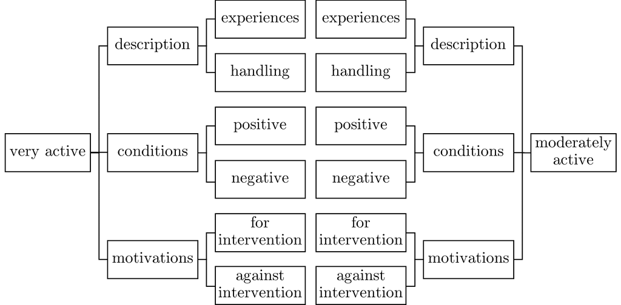

Figure 2.2: Overview of the final categorization

```r
# Note that the label for a figure is always fig:chunkname
knitr::include_graphics("../images/categorization.png")
```

# 3 Results

As figure 2.2) shows, we contrasted the results of both groups for each category, (*description*, *conditions* and *motivations*). As our research question focusses on predictors, only a quick overview will be given for the category *description*.

For the sake of brevity, in the following sections these terms will be used: *Hater:* The perpetrator of the hate speech, *victim(s):* the recipient(s) or subject(s) of the hate speech, and *adversary victim(s):* victim(s) or subject(s) of hate speech that represent a group the participant politically or personally opposes.

## 3.1 Description: Experiences with hate speech and handling hate speech

When describing their experiences with hate speech, both groups mention similar attributes of hate speech (e.g., the online *spaces* where they have most often observed it). However, while four of the six very active participants report to have themselves been victims of hate speech, only one moderately active participants does so as well. There are also notable differences in the way participants of both groups handle hate speech: While participants in the moderately active group tend to look at hateful comments only for entertainment value or avoid looking at comments at all, many participants in the very active groupactively seek out hate speech comments in order to fight it.

## 3.2 Conditions: When to engage in counter speech

For a given situation, participants describe both conditions that make it more likely that they engage in counter speech ( *positive conditions*) as well as conditions that make it less likely ( *negative conditions*). As mentioned above, the participants in the moderately active group reported to only seldomely engage in counter speech at all, much less counter speech favoring *adversary victims*, i.e., politically opposed users that are targetted by hate speech. Therefore, most of the conditions listed are to be understood as conditions for counter speech in general. The only exception is the subcategory *positive conditions* for the very active group where a differentiation between counter speech in general and counter speech favoring *adversary victims* was possible.

### 3.2.1 Positive conditions for counter speech favoring adversaries.

When it comes defending people who they are politically opposed to, the following conditions emerged in the very active group: **1) Offenses against a “culture of discussion”**, i.e., the participant feels that the hater breaks the rules for a respectful debate, **2) offenses against the human dignity**, i.e., the participant feels that the hater debases the victim’s human dignity, **3) properties of the victim**, e.g., the participants feels sympathy for the victim, and **4) a personal connection to the topic discussed**.

### 3.2.2 Positive conditions for counter speech in general.

#### 3.2.2.1 Properties of the hate speech.

Concerning the properties of the hate speech or the situation where the hate speech occurs, participants of both groups mention they are more likely to step in when they feel that their *counter speech is likely to have an impact*, e.g., there are not that many comments overall. Additionally, participants of the very active group name the space as an important factor. They are more likely to step in when there is hate speech **1) outside of hater-dominated spaces**, e.g., not in a dedicated facebook group, or **2) in a more private space**, e.g., in a personal chat group.

On the other side, participants of the moderately active group mention **3) calls to violence and threats** as well as **4) doxxing**, i.e., finding and disseminating the victim’s personal information, as factors making counter speech more likely for them.

#### 3.2.2.2 Properties of the victim.

Relating to the properties of the victim, both groups mention that they would be more likely to intervene if **1) the victim is a private citizen_** or if **2) they know the victim personally**, although that is more important in the moderately active group. Additionaly, particicpants of the very active group would be more likely to engage in counter speech if **3) the victim is an activist**.

#### 3.2.2.3 Personal attributes.

Participants of both group state that they are more likely to step in if they are **1) well informed about the topic of discussion**. Members of the very active group also name **2) free time and mental energy** as a condition. Some members of the moderately active group, on the other hand, describe **3) feeling frustrated and angry** or **4) having a personal connection** to the topic of discussion as a conductor for counter~speech.

### 3.2.3 Negative conditions for counter speech in general.

Many of the *negative conditions* mentioned in the group are merely negations of the *positive conditions* already listed and will therefore not be reported again.

#### 3.2.3.1 Properties of the hate speech.

Members of both group state that they are less likely to engage in counter speech, when **1) both sides of the discussion engage in hate speech** or when **2) the hate speech is entertaining to them**.

Additionally, participants of the very active group are less willing to intervene when they fear **3) personal risk to themselves**.

#### 3.2.3.2 Properties of the victim.

Apart from the negatives to the *positive conditions* already mentioned, one member of the very active group reports that they would be less likely to intervene if they suspect **the victim is eager to be seen as a victim by the public**.

## 3.3 Motivations: Why to engage in counter speech

Just as with the conditions, the *motivations* of the participants could also be categorized into *motivations for intervention* and *motivations against intervention*. In this context, *motivations* relate to the participants’ attitudes towards counter speech in general. By contrast, the *conditions* listed above relate to specific situations.

### 3.3.1 Motivations for intervention.

The *motivations for intervention* can be further categorized into *goals and values* and *personal attributes and experiences*.

#### 3.3.1.1 Goals and values.

Participants of both groups concede that while they might not be able to dissuade the hater from their destructive behavior, they still *hope to positively influence the audience*. Members of the very active group are additionally motivated by the desire to **1) fight disinformation**, **2) motivate critical thinking in other users**, **3) create a better culture of discussion in online spaces** and **4) engage politically**.

Moderately active participants, on the other hand, worry that *online hate might spark offline violence*.

#### 3.3.1.2 Personal attributes and experiences.

When it comes to their personal attributes and experiences that motivate them to engage in counter speech, participants of both groups mention **a strong sense of justice** and **a sense of responsibility**.

In addition, very active participants name **enjoying debating**, **their own experiences with bullying and discrimination**, **enjoying self-promotion**, as well as **being thanked and admired by others**, e.g., by site administrators, as motivators.

### 3.3.2 Motivations against intervention.

Members of both groups name one main motivation not to engage in counter speech: They think it is **not worth the effort**. On top of that, members of the very active group mainly mention **fatigue** with fighting hate speech in general as something that demotivates them from engaging in counter speech.

Among the moderately active participants, a considerable number more motivations are named:

1. *A general unwillingness to participate in online communication*,
2. *a preference for alternative approaches to hate speech*, e.g. blocking the perpetrator or even reporting them to the police,
3. *the chance to be successful is perceived as too small* and
4. *their own tendency to avoid reading comments at all*.

# 4 Discussion and Conclusion

Notably, a vast difference in engagement levels between the participants was found. While some would not engage in online discourse at all and consequently would not engage in counter speech either, others were hyperactive on social media, placing a lot of value on political discourse in online spaces. Participants in the latter group reported a much higher likelihood to engage in counter speech, be it on behalf of opponents or in general.

Three basic motivations for users to engage in counter speech in support of political adversaries can be differentiated: Firstly, the hater violates norms or values that are more important to the counter speaker than political affiliation. Values named here were a “culture of discussion”, i.e., an implicit set of rules for a respectful debate, and “human dignity”. These conditions tie somewhat into other findings about counter speakers placing high importance on morality (Lambe et al. 2019; Wilhelm and Joeckel 2019). Interestingly, they also mirror the vision of the internet as a place for public deliberation (Chen 2017). Productive debates can only happen if all participants follow the rules, no matter which side they are on. Secondly, counter speech is more likely if the participants feels sympathetic towards the victim. This is similar to results from cyber-bullying research (Lambe et al. 2019). Thirdly, participants are more likely to intervene when they feel a personal connection to the topic of discussion. Both the second and the third motivation are limited in their generalizability. Sympathies are likely to wane the larger the distance on the political spectrum gets. And in many occurences of hate speech, there will be no connection to a tangible discussion topic.

The other predictors we found refer to counter speech in general and therefore do not strictly answer the research question. However, as posited above, we did not observe the expected divide between people engaging in counter speech only for friends or members of their in-group and people engaging in counter speech for everyone—including adversaries. Rather, the divide was between people engaging in counter speech for everyone, regardless of political or group affiliation, and people not generally engaging in counter speech. As such, we feel that the *motivations* of the very active group questioned also partly answer the question of what motivates counter speakers.

The most important *motivations* we found were deep-seated moral convictions and a feeling of responsibility to uphold those convictions. This does not only match the findings by on the importance of morality by Wilhelm and Joeckel (2019) and Lambe et al. (2019). The acceptance of responsibility also matches the bystander model of intervention often used to describe bystander behavior in cyber-bullying incidents (e.g., (Naab, Kalch, and Meitz 2018)). Moreover, the participants felt that online discourse is an important part of political participation (Chen 2017). Many of the active counter speakers we talked to saw their actions as a form of activism. One of their major goals was not to change the behavior of the people engaging in hate speech, but to positively influence the broader audience. This matches what Buerger and Wright (2019) calls the contagion effect.

In conclusion, when looking at what motivates a person to regularly engage in counter speech, their relationship to the victim appears to be secondary. Of greater importance seems to be what part morality plays in that person’s self-image and how willing they are to accept and defend online spaces as a place for public deliberation.

# 5 Data and Materials

On this sub-page you can find the data used as a downloadable files.

## 5.1 Materials

You can find the following supplementary materials in the Github Repository:

These documents are in German:

- [Focus group guideline](https://github.com/digitalemuendigkeit/misdoom2020/raw/master/supplementarymaterial/Focus-Group-Guide-German.pdf)
- [Slides used in the focus group](https://github.com/digitalemuendigkeit/misdoom2020/raw/master/supplementarymaterial/Focus-Group-Slides-German.pdf)
- [Questionnaire in focus group](https://github.com/digitalemuendigkeit/misdoom2020/raw/master/supplementarymaterial/Questionnaire-German.pdf)
- [Transcript of Group “moderately active”](https://github.com/digitalemuendigkeit/misdoom2020/raw/master/supplementarymaterial/Transcript-Moderately-Active-Group-German.pdf)
- [Transcript of group “very active”](https://github.com/digitalemuendigkeit/misdoom2020/raw/master/supplementarymaterial/Transcript-Very-Active-Group-German.pdf)
- [Transcription system](https://github.com/digitalemuendigkeit/misdoom2020/raw/master/supplementarymaterial/Transcription-System-German.pdf)

You can also directly see all suppl. materials in the [github repository](https://github.com/digitalemuendigkeit/misdoom2020/tree/master/supplementarymaterial).

## 5.2 Data of participants

```r
data_df <- read.csv(file = "../data/participants.csv", header = TRUE, sep = ";",
    quote = "", dec = ",", fill = TRUE, nrows = 11, )


datatable(data_df, filter = list(position = "top", clear = TRUE, plain = FALSE),
    extensions = c("Buttons", "FixedColumns"), options = list(dom = "Bfrtip", buttons = c("copy",
        "csv", "excel", "pdf"), scrollX = TRUE, fixedColumns = TRUE))
```

|  | Chiffre..Nr_GeschlechtAlter. | Group.Number | Gender | Age | Frequency.of.Use..Social.Networking.Sites | Frequency.of.Use..Video.Platforms | Frequency.of.Use..Blogs | Frequency.of.Use..Online.Newspaper | Frequency.of.Use...Infotainment. | Frequency.uf.Use..Social.News | Frequency.of.Use..Overall..calculated. | Frequency.of.Posting.and.Commenting. | Left.Right.Self.Placement.. | Highest.Level.of.Education | Occupation |
| --- | --- | --- | --- | --- | --- | --- | --- | --- | --- | --- | --- | --- | --- | --- | --- |
| 1 | 01_m22 | 1 | m | 22 | 2 | 4 | 4 | 6 | 1 | 6 | 3.8 | 1 | 3 | General Higher Education Entrance Qualification (Abitur) | Student |
| 2 | 02_w24 | 1 | w | 24 | 6 | 6 | 1 | 2 | 1 | 3 | 3.2 | 3 | 4 | University Degree | Student |
| 3 | 03_m29 | 1 | m | 29 | 6 | 6 | 1 | 5 | 2 | 5 | 4.2 | 2 | 6 | University Degree | Engineer |
| 4 | 04_w26 | 1 | w | 26 | 4 | 4 | 1 | 5 | 1 | 2 | 2.8 | 2 | 4 | University Degree | Student |
| 5 | 05_m32 | 1 | m | 32 | 3 | 3 | 4 | 4 | 2 | 4 | 3.3 | 3 | 3 | University Degree | Software Developer |
| 6 | 06_w46 | 2 | w | 46 | 6 | 4 | 2 | 5 | 5 | 1 | 3.8 | 6 | 3 | University Degree | Translator |
| 7 | 07_m32 | 2 | m | 32 | 6 | 6 | 1 | 5 | 2 | 4 | 4 | 5 | 4 | General Higher Education Entrance Qualification (Abitur) | Software Developer |
| 8 | 08_w27 | 2 | w | 27 | 6 | 5 | 6 | 4 | 2 | 4 | 4.5 | 6 | 6 | University Degree | Doctoral Student |
| 9 | 09_m28 | 2 | m | 28 | 5 | 5 | 4 | 6 | 2 | 5 | 4.5 | 6 | 1 | University Degree | Student |
| 10 | 10_m32 | 2 | m | 32 | 5 | 6 | 1 | 4 | 3 | 4 | 3.8 | 4 | 4 | General Higher Education Entrance Qualification (Abitur) | Educator |

[output cut: 1 more lines]

```r
# rmdtemplates::line_cite(pkgs) # This creates a single line citing all packages
rmdtemplates::list_cite(pkgs)  # This creates a 'thightlist' of all packages
```

# 6 Used Packages

We used the following packages to create this document:

- Package: knitr by Xie (2019)
- Package: tidyverse by Wickham (2019)
- Package: rmdformats by Barnier (2019)
- Package: kableExtra by Zhu (2019)
- Package: rmdtemplates by Calero Valdez (2019)
- Package: DT by Xie, Cheng, and Tan (2019)

# Acknowledgements

We would like to thank Maximilian Geulen and Merten Wothge for their help in developing the research design as well as collecting the data. We would also like to thank Laura Burbach for her helpful comments on this paper. This research was supported by the Digital Society research program funded by the Ministry of Culture and Science of the German State of North Rhine-Westphalia. We would further like to thank the authors of the packages we have used.

```r
rmdtemplates::line_cite(pkgs)  # This creates a single line citing all packages
```

We used the following packages to create this document: `knitr` (Xie 2019), `tidyverse` (Wickham 2019), `rmdformats` (Barnier 2019), `kableExtra` (Zhu 2019), `rmdtemplates` (Calero Valdez 2019), `DT` (Xie, Cheng, and Tan 2019).

```r
# rmdtemplates::list_cite(pkgs) # This creates a 'thightlist' of all packages
```

# References

’Alvarez-Benjumea, Amalia, and Fabian Winter. 2018. “Normative Change and Culture of Hate: An Experiment in Online Environments.” *European Sociological Review* 34 (3): 223–37. https://doi.org/10.1093/esr/jcy005.

Awan, Imran. 2016. “Islamophobia on Social Media: A Qualitative Analysis of the Facebook’S Walls of Hate,” July. https://doi.org/10.5281/ZENODO.58517.

Barnier, Julien. 2019. *Rmdformats: HTML Output Formats and Templates for ’Rmarkdown’ Documents*. https://CRAN.R-project.org/package=rmdformats.

Benesch, Susan, Cathy Buerger, Tonei Glavinic, and Sean Manion. 2020. “Dangerous Speech: A Practical Guide.” *Dangerous Speech Project*. https://dangerousspeech.org/guide/.

Bennett, W Lance, and Steven Livingston. 2018. “The Disinformation Order: Disruptive Communication and the Decline of Democratic Institutions.” *European Journal of Communication* 33 (2): 122–39. https://doi.org/10.1177/0267323118760317.

Borah, Porismita. 2014. “Does It Matter Where You Read the News Story? Interaction of Incivility and News Frames in the Political Blogosphere.” *Communication Research* 41 (6): 809–27. https://doi.org/10.1177/0093650212449353.

Boulianne, Shelley. 2018. “Twenty Years of Digital Media Effects on Civic and Political Participation.” *Communication Research*, October. https://doi.org/10.1177/0093650218808186.

Brennan, Robert L., and Dale J. Prediger. 1981. “Coefficient Kappa: Some Uses, Misuses, and Alternatives.” *Educational and Psychological Measurement* 41 (3). Sage Publications Sage CA: Thousand Oaks, CA: 687–99.

Breyer, Bianka. n.d. “Left-Right Self-Placement (ALLBUS).” Zusammenstellung sozialwissenschaftlicher Items und Skalen.

Buerger, Cathy, and Lucas Wright. 2019. “Counterspeech: A Literature Review.” Dangerous Speech Project.

Calero Valdez, André. 2019. *Rmdtemplates: Rmdtemplates - an Opinionated Collection of Rmarkdown Templates*. https://github.com/statisticsforsocialscience/rmd_templates.

Campbell, John L., Charles Quincy, Jordan Osserman, and Ove K. Pedersen. 2013. “Coding in-Depth Semistructured Interviews: Problems of Unitization and Intercoder Reliability and Agreement.” *Sociological Methods & Research* 42 (3): 294–320. https://doi.org/10.1177/0049124113500475.

Chen, Gina Masullo. 2017. *Online Incivility and Public Debate*. Cham: Springer International Publishing. https://doi.org/1.

Coe, Kevin, Kate Kenski, and Stephen A. Rains. 2014. “Online and Uncivil? Patterns and Determinants of Incivility in Newspaper Website Comments.” *Journal of Communication* 64 (4): 658–79. https://doi.org/10.1111/jcom.12104.

Colleoni, Elanor, Alessandro Rozza, and Adam Arvidsson. 2014. “Echo Chamber or Public Sphere? Predicting Political Orientation and Measuring Political Homophily in Twitter Using Big Data: Political Homophily on Twitter.” *Journal of Communication* 64 (2): 317–32. https://doi.org/10.1111/jcom.12084.

Dickter, Cheryl L. 2012. “Confronting Hate: Heterosexuals’ Responses to Anti-Gay Comments.” *Journal of Homosexuality* 59 (8): 1113–30. https://doi.org/10.1080/00918369.2012.712817.

Dickter, Cheryl L., and Virginia A. Newton. 2013. “To Confront or Not to Confront: Non-Targets’ Evaluations of and Responses to Racist Comments: Responses to Racist Comments.” *Journal of Applied Social Psychology* 43 (June): E262–E275. https://doi.org/10.1111/jasp.12022.

Erjavec, Karmen. 2014. “Readers of Online News Comments: Why Do They Read Hate Speech Comments?” *Annales. Series Historia et Sociologia* 24 (3): 451–62.

Erjavec, Karmen, and Melita Poler Kovačič. 2012. “‘You Don’t Understand, This Is a New War!’ Analysis of Hate Speech in News Web Sites’ Comments.” *Mass Communication and Society* 15 (6): 899–920. https://doi.org/10.1080/15205436.2011.619679.

Feezell, Jessica T. 2016. “Predicting Online Political Participation: The Importance of Selection Bias and Selective Exposure in the Online Setting.” *Political Research Quarterly* 69 (3): 495–509. https://doi.org/10.1177/1065912916652503.

Gagliardone, Iginio, Danit Gal, Thiago Alves, and Gabriela Martines. 2015. “Countering Online Hate Speech.” Unesco.

Gensing, Patrick. 2018. “Grünen-Politikerin Roth: Im Visier des Hasses.” *Tagesschau.de*. http://www.tagesschau.dehttp://faktenfinder.tagesschau.de/inland/kampagnen-roth-101.html.

Hambauer, Verena, and Anja Mays. 2018. “Wer wählt die AfD? Ein Vergleich der Sozialstruktur, politischen Einstellungen und Einstellungen zu Flüchtlingen zwischen AfD-WählerInnen und der WählerInnen der anderen Parteien.” *Zeitschrift Für Vergleichende Politikwissenschaft* 12 (1): 133–54. https://doi.org/10.1007/s12286-017-0369-2.

Hwang, Hyunseo, Porismita Borah, Kang Namkoong, and Aaron S. Veenstra. 22AD. “Does Civility Matter in the Blogo- Sphere? Examining the Interaction Effects of Incivility and Disagreement on Citizen Attitudes.” In *Annual Convention of the International Communication Association*. Montreal, Canada.

Hwang, Hyunseo, Youngju Kim, and Catherine U. Huh. 2014. “Seeing Is Believing: Effects of Uncivil Online Debate on Political Polarization and Expectations of Deliberation.” *Journal of Broadcasting & Electronic Media* 58 (4): 621–33. https://doi.org/10.1080/08838151.2014.966365.

Jubany, Olga. 2016. “Backgrounds, Experiences and Responses to Online Hate Speech: An Ethnographic Multi-Sited Analysis.” In *2nd Annual International Conference on Social Science and Contemporary Humanity Development (SSCHD 2016)*. Atlantis Press. https://doi.org/10.2991/sschd-16.2016.143.

Kazerooni, Franccesca, Samuel Hardman Taylor, Natalya N Bazarova, and Janis Whitlock. 2018. “Cyberbullying Bystander Intervention: The Number of Offenders and Retweeting Predict Likelihood of Helping a Cyberbullying Victim.” *Journal of Computer-Mediated Communication* 23 (3): 146–62. https://doi.org/10.1093/jcmc/zmy005.

Kim, Yonghwan, and Youngju Kim. 2019. “Incivility on Facebook and Political Polarization: The Mediating Role of Seeking Further Comments and Negative Emotion.” *Computers in Human Behavior* 99 (October): 219–27. https://doi.org/10.1016/j.chb.2019.05.022.

Lambe, Laura J., Victoria Della Cioppa, Irene K. Hong, and Wendy M. Craig. 2019. “Standing up to Bullying: A Social Ecological Review of Peer Defending in Offline and Online Contexts.” *Aggression and Violent Behavior* 45 (March): 51–74. https://doi.org/10.1016/j.avb.2018.05.007.

Lees, Charles. 2018. “The ‘Alternative for Germany’: The Rise of Right-Wing Populism at the Heart of Europe.” *Politics* 38 (3): 295–310. https://doi.org/10.1177/0263395718777718.

Mader, Matthias, and Harald Schoen. 2019. “The European Refugee Crisis, Party Competition, and Voters’ Responses in Germany.” *West European Politics* 42 (1): 67–90. https://doi.org/10.1080/01402382.2018.1490484.

Mayring, Philipp. 2014. *Qualitative Content Analysis: Theoretical Foundation, Basic Procedures and Software Solution*. Klagenfurt.

Molina, Rocío Galarza, and Freddie J. Jennings. 2018. “The Role of Civility and Metacommunication in Facebook Discussions.” *Communication Studies* 69 (1): 42–66. https://doi.org/10.1080/10510974.2017.1397038.

Munger, Kevin. 2017. “Tweetment Effects on the Tweeted: Experimentally Reducing Racist Harassment.” *Political Behavior* 39 (3): 629–49. https://doi.org/10.1007/s11109-016-9373-5.

Naab, Teresa K, Anja Kalch, and Tino GK Meitz. 2018. “Flagging Uncivil User Comments: Effects of Intervention Information, Type of Victim, and Response Comments on Bystander Behavior.” *New Media & Society* 20 (2): 777–95. https://doi.org/10.1177/1461444816670923.

Papacharissi, Zizi. 2002. “The Virtual Sphere: The Internet as a Public Sphere.” *New Media & Society* 4 (1): 9–27. https://doi.org/10.1177/14614440222226244.

———. 2004. “Democracy Online: Civility, Politeness, and the Democratic Potential of Online Political Discussion Groups.” *New Media & Society* 6 (2): 259–83. https://doi.org/10.1177/1461444804041444.

Rains, Stephen A., Kate Kenski, Kevin Coe, and Jake Harwood. 2017. “Incivility and Political Identity on the Internet: Intergroup Factors as Predictors of Incivility in Discussions of News Online: Incivility and Political Identity Online.” *Journal of Computer-Mediated Communication* 22 (4): 163–78. https://doi.org/10.1111/jcc4.12191.

Schulz, Marlen, Birgit Mack, and Ortwin Renn, eds. 2012. *Fokusgruppen in Der Empirischen Sozialwissenschaft: Von Der Konzeption Bis Zur Auswertung*. Wiesbaden: Springer VS.

Selting, Margret, Peter Auer, Dagmar Barth-Weingarten, JÃ¶rg Bergmann, Pia Bergmann, Karin Birkner, Elizabeth Couper-Kuhlen, et al. 2011. “A System for Transcribing Talk-in-Interaction: GAT 2 Translated and Adapted for English by Elizabeth Couper-Kuhlen and Dagmar Barth-Weingarten.” *Gesprächsforschung - Online-Zeitschrift Zur Verbalen Interaktion*, no. 12: 1–51.

“Volksverhetzung: Hunderte Anzeigen Gegen AfD-Fraktionsvize von Storch | ZEIT ONLINE.” 2018. *Zeit.de*. https://www.zeit.de/politik/2018-01/volksverhetzung-beatrix-von-storch-strafanzeigen-silvester.

Waldron, Jeremy. 2012. *The Harm in Hate Speech*. Harvard University Press.

Wickham, Hadley. 2019. *Tidyverse: Easily Install and Load the ’Tidyverse’*. https://CRAN.R-project.org/package=tidyverse.

Wilhelm, Claudia, and Sven Joeckel. 2019. “Gendered Morality and Backlash Effects in Online Discussions: An Experimental Study on How Users Respond to Hate Speech Comments Against Women and Sexual Minorities.” *Sex Roles* 80 (7-8): 381–92. https://doi.org/10.1007/s11199-018-0941-5.

Wong, Randy Y. M., Christy M. K. Cheung, and Bo Xiao. 2016. “Combating Online Abuse: What Drives People to Use Online Reporting Functions on Social Networking Sites.” In, 415–24. IEEE. https://doi.org/10.1109/HICSS.2016.58.

Wright, Lucas, Derek Ruths, Kelly P Dillon, Haji Mohammad Saleem, and Susan Benesch. 2017. “Vectors for Counterspeech on Twitter.” In, 57–62. Association for Computational Linguistics. https://doi.org/10.18653/v1/W17-3009.

Xie, Yihui. 2019. *Knitr: A General-Purpose Package for Dynamic Report Generation in R*. https://CRAN.R-project.org/package=knitr.

Xie, Yihui, Joe Cheng, and Xianying Tan. 2019. *DT: A Wrapper of the Javascript Library ’Datatables’*. https://CRAN.R-project.org/package=DT.

Zhu, Hao. 2019. *KableExtra: Construct Complex Table with ’Kable’ and Pipe Syntax*. https://CRAN.R-project.org/package=kableExtra.

[^1]: The repo can be found here: (github.com/digitalemuendigkeit/misdoom2020).